# Upgrade metodológico 2026 — TCGA-THCA

2026-09-12

# Escopo

Esta análise é exploratória e geradora de hipóteses. Batch correction e deconvolução reduzem confundimento mensurável, mas não eliminam confundimento residual nem demonstram causalidade, eficácia terapêutica, especificidade tumoral ou prontidão nanomédica.

# Coortes e versões da matriz

| field | value |
| --- | --- |
| source | recount3 TCGA THCA |
| assay | raw_counts |
| annotation | GENCODE G026 |
| tumor_code | 01 |
| normal_code | 11 |
| n_tumor | 505 |
| n_normal | 59 |
| n_paired_participants | 59 |
| matrix_fingerprint_sha256 | c001dfd1dc547ae546b134dd3b67412ccffa856f159d43e4fb0e0147a2b84b39 |
| acquired | 2026-09-08 |

| matrix | PC | condition_R2 | source_R2 |
| --- | --- | --- | --- |
| raw | 1 | 0.804 | 0.784 |
| raw | 2 | 0.046 | 0.050 |
| raw | 3 | 0.001 | 0.078 |
| raw | 4 | 0.004 | 0.042 |
| raw | 5 | 0.006 | 0.009 |
| raw | 6 | 0.001 | 0.001 |
| raw | 7 | 0.001 | 0.001 |
| raw | 8 | 0.015 | 0.000 |
| raw | 9 | 0.001 | 0.001 |
| raw | 10 | 0.001 | 0.000 |
| batch_corrected | 1 | 0.659 | 0.487 |
| batch_corrected | 2 | 0.094 | 0.069 |
| batch_corrected | 3 | 0.021 | 0.016 |
| batch_corrected | 4 | 0.026 | 0.019 |
| batch_corrected | 5 | 0.000 | 0.000 |
| batch_corrected | 6 | 0.030 | 0.022 |
| batch_corrected | 7 | 0.028 | 0.021 |
| batch_corrected | 8 | 0.001 | 0.001 |
| batch_corrected | 9 | 0.005 | 0.004 |
| batch_corrected | 10 | 0.002 | 0.002 |

# Deconvolução

| method | completed | samples | nonconverged_samples | interpretation |
| --- | --- | --- | --- | --- |
| xCell | TRUE | 842 | NA | relative enrichment |
| EPIC | TRUE | 842 | 51 | estimated fractions; convergence audited per sample |
| multi_signature_ssgsea | TRUE | 842 | NA | reference score; not a fraction |

| status | samples |
| --- | --- |
| formal_fraction_converged | 791 |
| formal_fraction_nonconverged | 51 |

| gene | cell_type | percent_variance_unique | percent_variance_all_composition | raw_logFC | raw_FDR |
| --- | --- | --- | --- | --- | --- |
| RELN | fibroblast | 21.123 | 28.256 | -4.980 | 0 |
| FN1 | endothelial | 20.228 | 45.246 | 5.355 | 0 |
| MPPED2 | endothelial | 18.803 | 31.698 | -3.828 | 0 |
| WSCD2 | endothelial | 17.622 | 23.353 | -5.618 | 0 |
| AVPR1A | endothelial | 17.353 | 28.212 | -3.141 | 0 |
| GPC3 | fibroblast | 17.084 | 27.032 | -4.264 | 0 |
| RADIL | endothelial | 16.922 | 31.601 | -2.990 | 0 |
| MET | endothelial | 16.770 | 32.940 | 2.640 | 0 |
| SH2D6 | endothelial | 16.709 | 22.707 | -3.539 | 0 |
| PROX1-AS1 | endothelial | 16.416 | 21.106 | -3.254 | 0 |
| FN1 | fibroblast | 16.279 | 45.246 | 5.355 | 0 |
| PROS1 | endothelial | 15.644 | 29.302 | 3.461 | 0 |
| SPINT1 | endothelial | 13.850 | 33.514 | 1.676 | 0 |
| PBX4 | endothelial | 13.619 | 15.353 | -2.659 | 0 |
| SPX | endothelial | 13.110 | 27.425 | -3.526 | 0 |
| SERPINA1 | endothelial | 12.953 | 35.948 | 4.734 | 0 |
| MRO | endothelial | 12.667 | 20.914 | -4.767 | 0 |
| GALNT7 | endothelial | 12.609 | 15.132 | 2.263 | 0 |
| ZMAT3 | endothelial | 12.499 | 14.929 | 1.867 | 0 |
| RGS8 | endothelial | 12.139 | 16.764 | -5.729 | 0 |
| CLMN | endothelial | 11.845 | 19.935 | -2.148 | 0 |
| PLXND1 | endothelial | 11.379 | 30.254 | 1.660 | 0 |
| RP5-1024C24.1 | endothelial | 11.315 | 16.644 | -6.731 | 0 |
| STXBP5L | endothelial | 10.980 | 22.802 | -4.759 | 0 |
| PLXND1 | fibroblast | 10.899 | 30.254 | 1.660 | 0 |
| RP11-307B6.3 | endothelial | 10.747 | 27.285 | -2.681 | 0 |
| BMP8A | endothelial | 10.501 | 17.570 | -3.823 | 0 |
| ZFPM2 | fibroblast | 10.499 | 16.960 | -2.465 | 0 |
| GLT8D2 | fibroblast | 10.466 | 24.409 | -2.693 | 0 |
| ZMAT4 | endothelial | 10.371 | 16.354 | -6.351 | 0 |

Estimativas EPIC com otimização não convergente são mantidas, identificadas por amostra e tratadas como evidência de sensibilidade, não como frações definitivas.

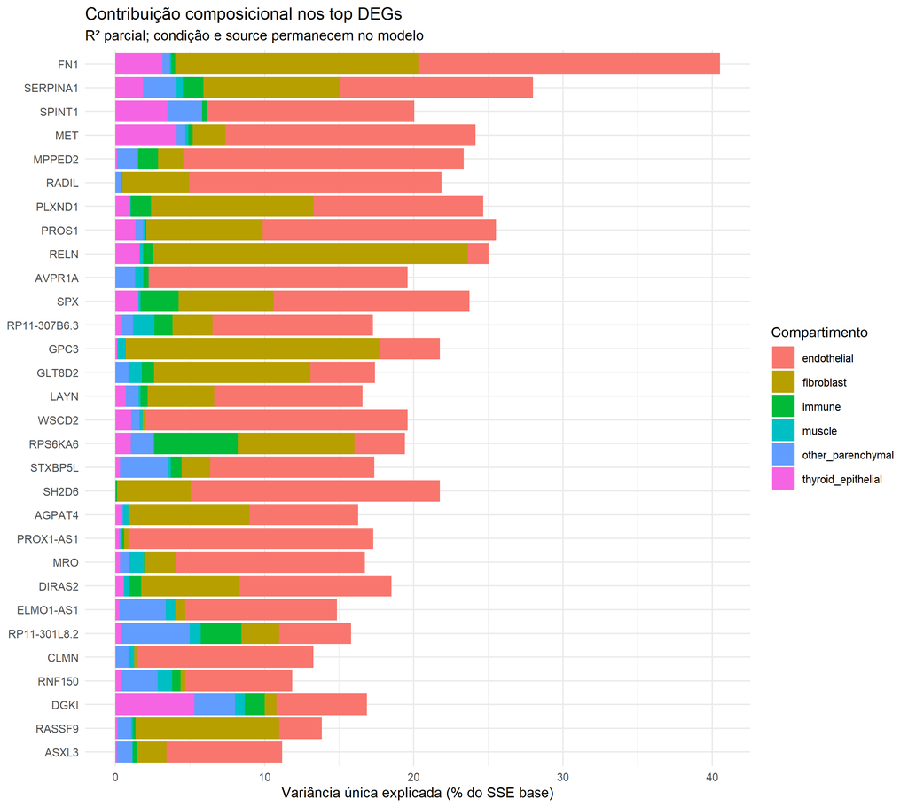

# Expressão diferencial

| variant | method | genes_tested | total_deg | up | down |
| --- | --- | --- | --- | --- | --- |
| tcga_matched | voom | 22787 | 3521 | 1557 | 1964 |
| tcga_matched | voom_quality_weights | 22787 | 4015 | 1961 | 2054 |
| tcga_matched | edgeR_QL | 22787 | 3270 | 1988 | 1282 |
| tcga_matched | DESeq2 | 22787 | 3224 | 1931 | 1293 |
| tcga_matched | limma_continuous | 22787 | 3489 | 1559 | 1930 |
| raw | voom | 22103 | 3218 | 1331 | 1887 |
| raw | voom_quality_weights | 22103 | 3677 | 1688 | 1989 |
| raw | edgeR_QL | 22103 | 2882 | 1653 | 1229 |
| raw | DESeq2 | 22103 | 2853 | 1624 | 1229 |
| raw | limma_continuous | 22103 | 3171 | 1324 | 1847 |
| batch_corrected | voom | 21446 | 3167 | 2158 | 1009 |
| batch_corrected | voom_quality_weights | 21446 | 3500 | 2348 | 1152 |
| batch_corrected | edgeR_QL | 21446 | 2827 | 1791 | 1036 |
| batch_corrected | DESeq2 | 21446 | 2795 | 1754 | 1041 |
| batch_corrected | limma_continuous | 21446 | 3099 | 1316 | 1783 |
| composition_adjusted | voom | 22103 | 2522 | 1088 | 1434 |
| composition_adjusted | voom_quality_weights | 22103 | 2592 | 1132 | 1460 |
| composition_adjusted | edgeR_QL | 22103 | 2263 | 1196 | 1067 |
| composition_adjusted | DESeq2 | 22103 | 2533 | 1449 | 1084 |
| composition_adjusted | limma_continuous | 22103 | 2675 | 803 | 1872 |
| tcga_paired | voom | 20984 | 2861 | 1501 | 1360 |
| tcga_paired | voom_quality_weights | 20984 | 3080 | 1572 | 1508 |
| tcga_paired | edgeR_QL | 20984 | 2975 | 1358 | 1617 |
| tcga_paired | DESeq2 | 20984 | 3009 | 1363 | 1646 |
| tcga_paired | limma_continuous | 20984 | 2999 | 1340 | 1659 |

# GSEA e robustez

| pathway | direction_fraction | significant_fraction | median_NES | robust | outlier_removed_NES | outlier_removed_FDR |
| --- | --- | --- | --- | --- | --- | --- |
| R-HSA-1474244 | 1.00 | 1.00 | 2.269 | TRUE | 2.304 | 0.000 |
| R-HSA-913531 | 1.00 | 0.99 | 1.589 | TRUE | 1.589 | 0.000 |
| hsa03030 | 1.00 | 1.00 | 2.036 | TRUE | 2.056 | 0.000 |
| hsa03050 | 1.00 | 1.00 | 2.341 | TRUE | 2.395 | 0.000 |
| hsa04010 | 1.00 | 1.00 | 1.541 | TRUE | 1.538 | 0.001 |
| hsa04110 | 1.00 | 1.00 | 1.937 | TRUE | 1.979 | 0.000 |
| hsa04115 | 1.00 | 1.00 | 2.350 | TRUE | 2.365 | 0.000 |
| hsa04151 | 1.00 | 1.00 | 1.519 | TRUE | 1.519 | 0.001 |
| hsa04210 | 1.00 | 1.00 | 1.895 | TRUE | 1.906 | 0.000 |
| hsa04218 | 1.00 | 1.00 | 1.863 | TRUE | 1.861 | 0.000 |
| hsa04510 | 1.00 | 1.00 | 1.859 | TRUE | 1.862 | 0.000 |
| hsa04512 | 1.00 | 1.00 | 1.668 | TRUE | 1.672 | 0.004 |
| hsa04668 | 1.00 | 0.79 | 1.468 | TRUE | 1.439 | 0.038 |
| hsa05216 | 1.00 | 0.70 | 1.558 | TRUE | 1.552 | 0.038 |
| R-HSA-3299685 | 1.00 | 0.01 | 1.158 | FALSE | 1.196 | 0.253 |
| hsa00190 | 0.85 | 0.03 | 0.800 | FALSE | 0.808 | 0.865 |
| hsa03440 | 1.00 | 0.04 | 1.320 | FALSE | 1.347 | 0.139 |
| hsa04064 | 0.95 | 0.00 | 1.030 | FALSE | 1.018 | 0.474 |
| hsa04066 | 1.00 | 0.10 | 1.293 | FALSE | 1.284 | 0.126 |
| hsa04140 | 0.87 | 0.00 | -0.923 | FALSE | -0.927 | 0.668 |
| hsa04150 | 1.00 | 0.00 | 0.969 | FALSE | 1.007 | 0.474 |
| hsa04216 | 0.90 | 0.00 | 0.884 | FALSE | 0.902 | 0.650 |
| hsa04310 | 0.91 | 0.00 | -1.116 | FALSE | -1.132 | 0.249 |
| hsa04350 | 1.00 | 0.03 | -1.215 | FALSE | -1.186 | 0.227 |
| hsa04390 | 1.00 | 0.06 | 1.164 | FALSE | 1.174 | 0.171 |
| hsa04612 | 0.95 | 0.19 | 1.208 | FALSE | 1.187 | 0.239 |
| hsa04620 | 1.00 | 0.35 | 1.345 | FALSE | 1.320 | 0.115 |
| hsa04630 | 1.00 | 0.48 | 1.371 | FALSE | 1.357 | 0.071 |
| hsa04657 | 1.00 | 0.00 | 1.114 | FALSE | 1.082 | 0.354 |
| hsa04919 | 1.00 | 0.14 | 1.265 | FALSE | 1.290 | 0.115 |

| variant | method | collection | pathway | NES | padj | leading_edge_n | composition_overlap_n | composition_overlap |
| --- | --- | --- | --- | --- | --- | --- | --- | --- |
| composition_adjusted | voom_qw | Hallmark | HALLMARK_EPITHELIAL_MESENCHYMAL_TRANSITION | 2.869 | 0 | 90 | 4 | COL1A1\|COL3A1\|COL1A2\|FAP |
| raw | voom_qw | Reactome | Eukaryotic Translation Elongation | 2.807 | 0 | 67 | 0 |  |
| tcga_matched | voom_qw | Reactome | Eukaryotic Translation Elongation | 2.791 | 0 | 68 | 0 |  |
| raw | voom_qw | Reactome | Formation of a pool of free 40S subunits | 2.764 | 0 | 69 | 0 |  |
| tcga_paired | DESeq2 | Reactome | Eukaryotic Translation Elongation | 2.748 | 0 | 80 | 0 |  |
| raw | voom_qw | Reactome | Peptide chain elongation | 2.741 | 0 | 62 | 0 |  |
| tcga_matched | voom_qw | Reactome | Formation of a pool of free 40S subunits | 2.737 | 0 | 70 | 0 |  |
| raw | voom_qw | Reactome | L13a-mediated translational silencing of Ceruloplasmin expression | 2.736 | 0 | 74 | 0 |  |
| tcga_matched | voom_qw | Reactome | Peptide chain elongation | 2.734 | 0 | 63 | 0 |  |
| tcga_matched | voom_qw | Reactome | L13a-mediated translational silencing of Ceruloplasmin expression | 2.728 | 0 | 75 | 0 |  |
| tcga_matched | voom_qw | Reactome | Ribosome Quality Control (RQC) complex extracts and degrades nascent peptide | 2.715 | 0 | 69 | 0 |  |
| tcga_paired | DESeq2 | Reactome | Peptide chain elongation | 2.712 | 0 | 75 | 0 |  |
| composition_adjusted | voom_qw | Reactome | Syndecan interactions | 2.693 | 0 | 21 | 3 | COL1A1\|COL3A1\|COL1A2 |
| tcga_paired | DESeq2 | KEGG | KEGG_RIBOSOME | 2.692 | 0 | 72 | 0 |  |
| raw | voom_qw | KEGG | KEGG_RIBOSOME | 2.685 | 0 | 68 | 0 |  |
| tcga_matched | voom_qw | Reactome | Cap-dependent Translation Initiation | 2.685 | 0 | 80 | 0 |  |
| tcga_matched | voom_qw | Reactome | Eukaryotic Translation Initiation | 2.685 | 0 | 80 | 0 |  |
| tcga_matched | voom_qw | KEGG | KEGG_RIBOSOME | 2.677 | 0 | 68 | 0 |  |
| raw | voom_qw | Reactome | Eukaryotic Translation Termination | 2.676 | 0 | 62 | 0 |  |
| raw | voom_qw | Reactome | Ribosome Quality Control (RQC) complex extracts and degrades nascent peptide | 2.675 | 0 | 69 | 0 |  |
| raw | voom_qw | Reactome | Nonsense Mediated Decay (NMD) independent of the Exon Junction Complex (EJC) | 2.673 | 0 | 64 | 0 |  |
| raw | voom_qw | Reactome | Cap-dependent Translation Initiation | 2.673 | 0 | 78 | 0 |  |
| raw | voom_qw | Reactome | Eukaryotic Translation Initiation | 2.673 | 0 | 78 | 0 |  |
| raw | voom_qw | Reactome | Viral mRNA Translation | 2.670 | 0 | 61 | 0 |  |
| batch_corrected | voom_qw | GO_BP | GOBP_HOMOPHILIC_CELL_CELL_ADHESION | 2.668 | 0 | 69 | 0 |  |
| composition_adjusted | voom_qw | Reactome | Eukaryotic Translation Elongation | 2.668 | 0 | 68 | 0 |  |
| raw | voom_qw | Reactome | Ribosome-associated quality control | 2.666 | 0 | 96 | 0 |  |
| tcga_matched | voom_qw | Reactome | Ribosome-associated quality control | 2.664 | 0 | 93 | 0 |  |
| tcga_matched | voom_qw | Reactome | SCF(Skp2)-mediated degradation of p27/p21 | 2.660 | 0 | 36 | 0 |  |
| tcga_matched | voom_qw | Reactome | Viral mRNA Translation | 2.657 | 0 | 62 | 0 |  |

# Meta-análise e sobrevivência

| gene | k | meta_logFC | meta_se | ci_low | ci_high | p | I2 | FDR |
| --- | --- | --- | --- | --- | --- | --- | --- | --- |
| ITGA2 | 3 | 2.423 | 0.249 | 1.935 | 2.910 | 0 | 66.726 | 0 |
| FN1 | 3 | 3.780 | 0.805 | 2.201 | 5.359 | 0 | 96.395 | 0 |
| CCND1 | 3 | 1.454 | 0.224 | 1.015 | 1.894 | 0 | 90.913 | 0 |
| TP53 | 1 | NA | NA | NA | NA | NA | NA | NA |
| CDK1 | 1 | NA | NA | NA | NA | NA | NA | NA |
| CDKN1A | 1 | NA | NA | NA | NA | NA | NA | NA |
| CCNB1 | 1 | NA | NA | NA | NA | NA | NA | NA |
| CCNB2 | 1 | NA | NA | NA | NA | NA | NA | NA |
| CCND2 | 1 | NA | NA | NA | NA | NA | NA | NA |
| CDK4 | 1 | NA | NA | NA | NA | NA | NA | NA |
| CDKN2A | 1 | NA | NA | NA | NA | NA | NA | NA |
| CHEK1 | 1 | NA | NA | NA | NA | NA | NA | NA |
| MDM2 | 1 | NA | NA | NA | NA | NA | NA | NA |
| SFN | 1 | NA | NA | NA | NA | NA | NA | NA |
| MCM2 | 1 | NA | NA | NA | NA | NA | NA | NA |
| MCM3 | 1 | NA | NA | NA | NA | NA | NA | NA |
| MCM4 | 1 | NA | NA | NA | NA | NA | NA | NA |
| MCM5 | 1 | NA | NA | NA | NA | NA | NA | NA |
| PCNA | 1 | NA | NA | NA | NA | NA | NA | NA |
| PSME1 | 1 | NA | NA | NA | NA | NA | NA | NA |

| gene | endpoint | stratum_type | stratum | n | events | HR | ci_low | ci_high | p | model_type | adjustment |
| --- | --- | --- | --- | --- | --- | --- | --- | --- | --- | --- | --- |
| MCM3 | OS | mutation | BRAF | 286 | 8 | 0.008 | 0.001 | 0.082 | 0.000 | expression_only_low_events | none |
| MCM3 | OS | histology | THCA | 480 | 14 | 0.057 | 0.012 | 0.283 | 0.000 | expression_only_low_events | none |
| PSME1 | OS | all | all | 497 | 16 | 0.104 | 0.029 | 0.373 | 0.001 | expression_only_low_events | none |
| CCNB1 | PFS | all | all | 495 | 51 | 2.704 | 1.538 | 4.754 | 0.001 | clinically_adjusted | age+stage_advanced+sex |
| MCM3 | OS | all | all | 497 | 16 | 0.076 | 0.017 | 0.338 | 0.001 | expression_only_low_events | none |
| CCNB1 | PFS | histology | THCA | 478 | 48 | 3.235 | 1.614 | 6.487 | 0.001 | clinically_adjusted | age+stage_advanced+sex |
| PSME1 | OS | histology | THCA | 480 | 14 | 0.102 | 0.026 | 0.402 | 0.001 | expression_only_low_events | none |
| CCNB1 | PFS | mutation | WT_or_other | 153 | 9 | 4.364 | 1.793 | 10.618 | 0.001 | expression_only_low_events | none |
| TP53 | DSS | histology | THCA | 480 | 5 | 38.243 | 4.144 | 352.955 | 0.001 | expression_only_low_events | none |
| CDKN2A | OS | mutation | BRAF | 286 | 8 | 2.087 | 1.313 | 3.315 | 0.002 | expression_only_low_events | none |
| PCNA | OS | mutation | BRAF | 286 | 8 | 0.075 | 0.015 | 0.385 | 0.002 | expression_only_low_events | none |
| CCND2 | DSS | all | all | 497 | 7 | 0.413 | 0.233 | 0.734 | 0.003 | expression_only_low_events | none |
| CCNB2 | PFS | all | all | 495 | 51 | 1.630 | 1.181 | 2.250 | 0.003 | clinically_adjusted | age+stage_advanced+sex |
| CCNB2 | PFS | histology | THCA | 478 | 48 | 1.706 | 1.180 | 2.465 | 0.005 | clinically_adjusted | age+stage_advanced+sex |
| PSME1 | OS | mutation | BRAF | 286 | 8 | 0.018 | 0.001 | 0.291 | 0.005 | expression_only_low_events | none |
| PCNA | OS | all | all | 497 | 16 | 0.263 | 0.104 | 0.666 | 0.005 | expression_only_low_events | none |
| CCNB1 | DSS | all | all | 497 | 7 | 5.578 | 1.645 | 18.913 | 0.006 | expression_only_low_events | none |
| MCM5 | OS | mutation | BRAF | 286 | 8 | 0.157 | 0.040 | 0.610 | 0.008 | expression_only_low_events | none |
| CDKN1A | PFS | mutation | WT_or_other | 153 | 9 | 0.410 | 0.213 | 0.791 | 0.008 | expression_only_low_events | none |
| CCND1 | DSS | all | all | 497 | 7 | 0.314 | 0.130 | 0.760 | 0.010 | expression_only_low_events | none |
| CDKN2A | OS | histology | THCA | 480 | 14 | 1.468 | 1.089 | 1.979 | 0.012 | expression_only_low_events | none |
| TP53 | OS | mutation | BRAF | 286 | 8 | 11.264 | 1.645 | 77.116 | 0.014 | expression_only_low_events | none |
| CCND2 | DSS | histology | THCA | 480 | 5 | 0.415 | 0.205 | 0.840 | 0.015 | expression_only_low_events | none |
| PCNA | OS | histology | THCA | 480 | 14 | 0.286 | 0.104 | 0.789 | 0.016 | expression_only_low_events | none |
| MCM3 | DSS | histology | THCA | 480 | 5 | 0.044 | 0.003 | 0.604 | 0.019 | expression_only_low_events | none |
| TP53 | DSS | all | all | 497 | 7 | 9.303 | 1.373 | 63.035 | 0.022 | expression_only_low_events | none |
| TP53 | PFS | histology | THCA | 478 | 48 | 2.382 | 1.120 | 5.064 | 0.024 | clinically_adjusted | age+stage_advanced+sex |
| CCND2 | OS | all | all | 497 | 16 | 0.570 | 0.347 | 0.934 | 0.026 | expression_only_low_events | none |
| CDK1 | PFS | all | all | 495 | 51 | 1.599 | 1.057 | 2.419 | 0.026 | clinically_adjusted | age+stage_advanced+sex |
| CCND2 | PFS | mutation | RAS | 58 | 8 | 0.367 | 0.150 | 0.897 | 0.028 | expression_only_low_events | none |

| gene | HPA_available | plasma_membrane | protein_evidence | antibody_localization_evidence | surfaceome_evidence | uniprot_membrane_annotation |
| --- | --- | --- | --- | --- | --- | --- |
| ITGA2 | TRUE | FALSE | TRUE | FALSE | TRUE | TRUE |
| FN1 | TRUE | FALSE | TRUE | FALSE | TRUE | TRUE |
| CCND1 | TRUE | FALSE | TRUE | FALSE | TRUE | TRUE |
| TP53 | TRUE | FALSE | TRUE | FALSE | TRUE | TRUE |
| CDK1 | TRUE | FALSE | TRUE | FALSE | TRUE | TRUE |
| CDKN1A | TRUE | FALSE | TRUE | FALSE | TRUE | TRUE |
| CCNB1 | TRUE | FALSE | TRUE | FALSE | TRUE | TRUE |
| CCNB2 | TRUE | FALSE | TRUE | FALSE | TRUE | TRUE |
| CCND2 | TRUE | FALSE | TRUE | FALSE | TRUE | TRUE |
| CDK4 | TRUE | FALSE | TRUE | FALSE | TRUE | TRUE |
| CDKN2A | TRUE | FALSE | TRUE | FALSE | TRUE | TRUE |
| CHEK1 | TRUE | FALSE | TRUE | FALSE | TRUE | TRUE |
| MDM2 | TRUE | FALSE | TRUE | FALSE | TRUE | TRUE |
| SFN | TRUE | FALSE | TRUE | FALSE | TRUE | TRUE |
| MCM2 | TRUE | FALSE | TRUE | FALSE | TRUE | TRUE |
| MCM3 | TRUE | FALSE | TRUE | FALSE | TRUE | TRUE |
| MCM4 | TRUE | FALSE | TRUE | FALSE | TRUE | TRUE |
| MCM5 | TRUE | FALSE | TRUE | FALSE | TRUE | TRUE |
| PCNA | TRUE | FALSE | TRUE | FALSE | TRUE | TRUE |
| PSME1 | TRUE | FALSE | TRUE | FALSE | TRUE | TRUE |

As fontes de superfície são Human Protein Atlas, tabela SURFY do Human Surfaceome e UniProt revisado; dados clínicos/moleculares provêm do cBioPortal e permanecem cacheados com versão. Presença nessas fontes não demonstra internalização nem disponibilidade de um anticorpo ou ligante terapêutico adequado.

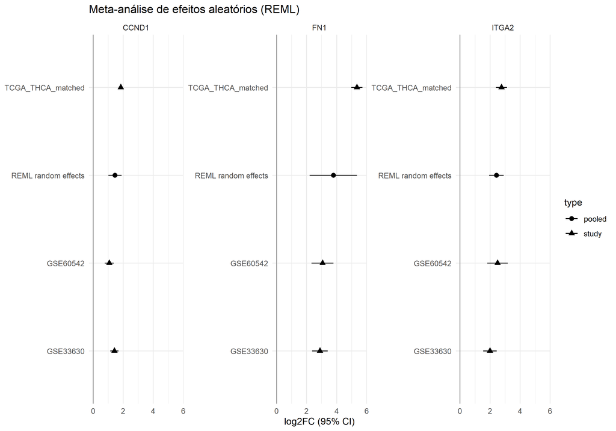

# Gate pré-especificado de ITGA2

| criterion | passed | classification |
| --- | --- | --- |
| direction_consistency | TRUE | DEG robusto de interesse |
| meta_effect | TRUE | DEG robusto de interesse |
| heterogeneity | TRUE | DEG robusto de interesse |
| surface_and_protein | FALSE | DEG robusto de interesse |
| composition_independence | TRUE | DEG robusto de interesse |
| survival_not_contradictory | TRUE | DEG robusto de interesse |

A classificação acima é calculada mecanicamente pelos critérios congelados em `docs/METHODOLOGICAL_UPGRADE_2026.md`. Centralidade PPI não entra nesse gate.

# PPI com evidência experimental e coexpressão

| network | input_genes | experimental_edges | coexpressed_edges | nodes | status |
| --- | --- | --- | --- | --- | --- |
| genome_wide_top500 | 500 | 26 | 20 | 34 | completed |
| panel30 | 2134 | 10157 | 5342 | 1333 | completed |
| robust_leading_edge | 3530 | 5059 | 3318 | 1109 | completed |

As centralidades são descritores topológicos; não constituem evidência terapêutica.

# Reprodutibilidade e desempenho

| step | status | elapsed_seconds | input_signature_sha256 | output_signature_sha256 |
| --- | --- | --- | --- | --- |
| 20_upgrade_config.R | completed | 7.92 | 6c7073e0b7e2cebc45bab2bd49d13356051c729b0e7d5015ce51d2a26f35043f | none |
| 21_tcga_adjacent_normal.R | completed | 55.07 | 2faa11315a870bc079858b35cc799a73a7eadd51373e2a6cfb9480dcc1291acc | 61c9af8e7e4c4545bc37e4a917bfb7210a7f6fe9aada20877d17b2fe1ae8a1c4 |
| 22_batch_correction.R | completed | 6728.10 | 320adf098de1ad9b9fb8743ccc9be2a7b0e53229b677330cbe0c8a254dddad01 | 59b5f0baa6d85ea390570bf71690b095d31e206730b86e38d9d4d9a66f6573ef |
| 23_deconvolution.R | failed | 51.93 | a232f1fdfe8c951030960e2cf55e1698bad9c59c938be2f47ec71ae133da74d2 | none |
| 23_deconvolution.R | failed | 20.98 | a639f477022f12a6f2f8e0db681a9a99906710a6469aae130a680e3209f17c4f | none |
| 23_deconvolution.R | completed | 50.30 | da80abf014ec53b6713ea1023b1c7845a31370f30582b79060a1cff73990d9e1 | 8f69c74ac1033db23de8fbf72ce0ba16a11847f10fa28a286126c7fce7d3e324 |
| 23_deconvolution.R | completed | 158.22 | 2549b041d9db7db71d21ac6c687555aade38102f0353be8eed018d1d2039c0b7 | 987bec760807a3e5f7e1f3caa98bda7e8bbdd6a1f144b7d668f7ab437d06581b |
| 24_multiverse_de.R | failed | 400.74 | be549fae28ea365c01f7d6d2124cbb0bff99f486904b30f6506aa5e390325020 | none |
| 24_multiverse_de.R | failed | 257.30 | c0d4e1d39c510183c360cc469a76d5a574d49a217674cc76cc0b72f5c5cee339 | none |
| 24_multiverse_de.R | failed | 485.78 | 4630157884244ddfa13aa2264794f7cd26af1e223d19447663bdd830d69165ce | none |
| 24_multiverse_de.R | completed | 29668.00 | 0bd187f3278297c5e0be4211bb3e5f34e00604eaee75846354ae5945b7109d9c | 4a1b7397fc1b4e46e5067dbf742ca23760ff43daada306fa13cb4e253191820d |
| 25_multiverse_gsea.R | completed | 6024.16 | 1699010ec1231964142b4672debc48f635a3eb3cee063f637c5049c8c548fef5 | 1518b1e07f29bd3a599303cc9ce6b2782b60ead87ba52052bb09ef403454d6f4 |
| 26_composition_variance.R | completed | 9.74 | cae866be32ceb43618c780ab0e9ccc45f20775b1f1e3469966ba0fb95595261f | 19da7815296e7d0e5cb232c89fa28f89cb6ebb085ba720077eff31e56f909cf1 |
| 27_validation_meta_survival_surface.R | failed | 12.04 | f4a09a435c623bf3d5106aaa3402d84156941f54494d578279e6efc2b1e06191 | ab1064c0e13a8793f8d85a4c7a1a7fd60ef7e6d7d8f3a483a73b1070538ba4e3 |
| 27_validation_meta_survival_surface.R | completed | 33.82 | f7b0be94c0f0d74659ce7d44fc476701fc85a48509a8339ef3b5615a974a0a23 | 30359ef413f3f0e657f5ccf5897922e633e34f32bb99b470f862f6811f690473 |
| 28_ppi_multinetwork.R | failed | 27.99 | 5f44f12ce0c4fddb71660debd86c18eb391681a597bc13bbddc8098fcdc2efe6 | none |
| 28_ppi_multinetwork.R | failed | 45.50 | da2b902805bd29e2a4f18d11c0f934de88c226f2f6351dead8a9d2e2a3bc2b57 | none |
| 28_ppi_multinetwork.R | completed | 1214.77 | a496dc94bfe35fce08f5b1d15d98609e1dc08fcaa445ac075b2b1e0b8ca87aa6 | 3369ec84292bd0e476ab7e8c6b6024eb723b7b0ea3b3ac3811a4320b156e4588 |
| 29_gsea_robustness.R | completed | 9857.79 | d626ac59199e34f068f3347dd03e83918de89b596cb6d581872b81eb7a7f101f | 4ba8203b1fac505df773d5040e160205ce1499d24a9cf7c3ae77e571e3f79e86 |
| 30_render_upgrade_report.R | completed | 11.71 | 7eda03a47c1952781c9f05606e5c8e03dbbcb6165a2fa60684447ea186c5aafb | 45126a439f8e3dab0cc6541d10ad0a0eed9ee9896e0d7a9397c44f1cdf418d79 |
| 31_validate_upgrade.R | failed | 17.52 | 176799d04780b7a973bb1e1cfc03492b4f0d79a7366bc7f6392f5e7a7f7e1811 | none |
| 31_validate_upgrade.R | failed | 25.90 | c16a6f67e10fc506645c0bc5371438e0210acdf64d9f731c26ccc12434f158db | 843fc61e9a9014d425d9ec671d3b8a467cd1b12db77e8975fec80bd545f19da3 |
| 27_validation_meta_survival_surface.R | completed | 89.73 | 04d65ab3c3b5ba4d29a467c5963bc36fcbb8ea8642d1e46afd9b9799de79ef33 | 30359ef413f3f0e657f5ccf5897922e633e34f32bb99b470f862f6811f690473 |
| 28_ppi_multinetwork.R | cached | 0.03 | a496dc94bfe35fce08f5b1d15d98609e1dc08fcaa445ac075b2b1e0b8ca87aa6 | 3369ec84292bd0e476ab7e8c6b6024eb723b7b0ea3b3ac3811a4320b156e4588 |
| 29_gsea_robustness.R | cached | 0.01 | d626ac59199e34f068f3347dd03e83918de89b596cb6d581872b81eb7a7f101f | 4ba8203b1fac505df773d5040e160205ce1499d24a9cf7c3ae77e571e3f79e86 |
| 30_render_upgrade_report.R | cached | 0.01 | 7eda03a47c1952781c9f05606e5c8e03dbbcb6165a2fa60684447ea186c5aafb | 45126a439f8e3dab0cc6541d10ad0a0eed9ee9896e0d7a9397c44f1cdf418d79 |
| 31_validate_upgrade.R | completed | 67.64 | c16a6f67e10fc506645c0bc5371438e0210acdf64d9f731c26ccc12434f158db | 74042d1a929907a20e4a54b999bc2504d0441e8e0c70503b75150d3022e65bfc |

# Limitações residuais

Normais adjacentes podem conter field effects e são menos numerosos que os tumores. Estimativas de composição dependem das assinaturas. Correção de batch pode remover sinal biológico real. A meta-análise agrega plataformas heterogêneas e aproxima erros-padrão quando apenas logFC e p-value estão disponíveis. THCA tem poucos eventos de sobrevida. Anotação de membrana não prova internalização, segurança ou janela terapêutica.